# Lab 7_Solutions

## Lab 7

In this lab we will practice working with raster data, in this case in the context of climate models. I have given you 4 sets of data:

1. Climate Model Data_Historic - this is a NetCDF file with output from a climate model. Data is monthly average air temperature for 1920-2005
2. Climate Model Data_Future - this is a NetCDF file with climate model output for the period 2006-2080
3. Observed Temp Data - this is gridded data based on weather station and satellite data. Data is monthly for 1991-2000
4. Population data - gridded counts of population for a number of years

The first part of the lab will compare modeled and observed climate data for major cities around the world. The second part of the lab will combine the population data and future climate data to project future changes in global temperature.

### Part 1

1a. Read in the historic climate model data as a SpatRaster. Use “TREFHT” (temperature at reference height) in the subds (sub-dataset) argument.

```r
#read in terra package
library(terra)
```

```r
#read in historic climate model
Data_Historic <- rast("~/Downloads/ESP_106/ESP 106/esp106_CandyGArellano/Week 7/Data/Climate Model Data_Historic/b.e11.B20TRC5CNBDRD.f09_g16.002.cam.h0.TREFHT.192001-200512.nc", subds = "TREFHT" )

#inspect
Data_Historic
```

```
## class       : SpatRaster
## dimensions  : 192, 288, 1032  (nrow, ncol, nlyr)
## resolution  : 1.25, 0.9424084  (x, y)
## extent      : -0.625, 359.375, -90.4712, 90.4712  (xmin, xmax, ymin, ymax)
## coord. ref. : +proj=longlat +datum=WGS84 +no_defs
## source      : b.e11.B20TRC5CNBDRD.f09_g16.002.cam.h0.TREFHT.192001-200512.nc:TREFHT
## varname     : TREFHT (Reference height temperature)
## names       : TREFHT_1, TREFHT_2, TREFHT_3, TREFHT_4, TREFHT_5, TREFHT_6, ...
## unit        :        K,        K,        K,        K,        K,        K, ...
## time (days) : 1920-02-01 to 2006-01-01 (2 steps)
```

1b. Use `ext` to see the longitude and latitude range of the SpatRaster you created. Note that the longitude goes form 0 to 360 (ish) instead of the more typical -180 to 180. This will cause a problem later on so use the `rotate` function to change the longitude coordinates. Use extent again on the rotated object to check the longitude goes from -180 to 180 (ish)

```r
#see longitude and latitude
ext(Data_Historic)
```

```
## SpatExtent : -0.625, 359.375, -90.4712041884817, 90.4712041884817 (xmin, xmax, ymin, ymax)
```

```r
#notes on rotate function
?rotate #for SpatRaster: rotate(x, left = TRUE, filename = "", ...)

#rotate SpatRaster as new object
R_Data_Historic <- rotate(Data_Historic, left=TRUE)
```

```
## |---------|---------|---------|---------|=========================================
```

```r
#check longitude goes from -180 to 180ish

ext(R_Data_Historic) #it worked
```

```
## SpatExtent : -180.625, 179.375, -90.4712041884817, 90.4712041884817 (xmin, xmax, ymin, ymax)
```

2a. Use `rnaturalearth::ne_download()` function to get a SpatVector object of major cities (“populated_places”), and subset it to get just the 10 most populous cities based on 2020 population (POP2020 column)

```r
#Hint 1: Check the object type of the POP2020 column. If necessary convert to a numeric vector using as.numeric()

#Hint 2: The function order() will give you the index value corresponding to the ascending or descending numerical order of a column

#install package
##install.packages("rnaturalearth")

#References: https://www.rdocumentation.org/packages/rnaturalearth/versions/1.2.0/topics/ne_download
```

```r
?ne_download
```

```
## No documentation for 'ne_download' in specified packages and libraries:
## you could try '??ne_download'
```

```r
#get SpatVector object of major cities

cities <- rnaturalearth::ne_download(scale = 10, #high resolution.
                                     type = "populated_places",
                                     category = c( "cultural"),
                                     returnclass = c("sv"))
```

```
## Reading 'ne_10m_populated_places.zip' from naturalearth...
```

```r
#results
class(cities)
```

```
## [1] "SpatVector"
## attr(,"package")
## [1] "terra"
```

```r
nrow(cities)
```

```
## [1] 7342
```

```r
names(cities)
```

```
##   [1] "SCALERANK"  "NATSCALE"   "LABELRANK"  "FEATURECLA" "NAME"
##   [6] "NAMEPAR"    "NAMEALT"    "NAMEASCII"  "ADM0CAP"    "CAPIN"
##  [11] "WORLDCITY"  "MEGACITY"   "SOV0NAME"   "SOV_A3"     "ADM0NAME"
##  [16] "ADM0_A3"    "ADM1NAME"   "ISO_A2"     "NOTE"       "LATITUDE"
##  [21] "LONGITUDE"  "POP_MAX"    "POP_MIN"    "POP_OTHER"  "RANK_MAX"
##  [26] "RANK_MIN"   "MEGANAME"   "LS_NAME"    "MAX_POP10"  "MAX_POP20"
##  [31] "MAX_POP50"  "MAX_POP300" "MAX_POP310" "MAX_NATSCA" "MIN_AREAKM"
##  [36] "MAX_AREAKM" "MIN_AREAMI" "MAX_AREAMI" "MIN_PERKM"  "MAX_PERKM"
##  [41] "MIN_PERMI"  "MAX_PERMI"  "MIN_BBXMIN" "MAX_BBXMIN" "MIN_BBXMAX"
##  [46] "MAX_BBXMAX" "MIN_BBYMIN" "MAX_BBYMIN" "MIN_BBYMAX" "MAX_BBYMAX"
##  [51] "MEAN_BBXC"  "MEAN_BBYC"  "TIMEZONE"   "UN_FID"     "POP1950"
##  [56] "POP1955"    "POP1960"    "POP1965"    "POP1970"    "POP1975"
##  [61] "POP1980"    "POP1985"    "POP1990"    "POP1995"    "POP2000"
##  [66] "POP2005"    "POP2010"    "POP2015"    "POP2020"    "POP2025"
##  [71] "POP2050"    "MIN_ZOOM"   "WIKIDATAID" "WOF_ID"     "CAPALT"
##  [76] "NAME_EN"    "NAME_DE"    "NAME_ES"    "NAME_FR"    "NAME_PT"
##  [81] "NAME_RU"    "NAME_ZH"    "LABEL"      "NAME_AR"    "NAME_BN"
##  [86] "NAME_EL"    "NAME_HI"    "NAME_HU"    "NAME_ID"    "NAME_IT"
##  [91] "NAME_JA"    "NAME_KO"    "NAME_NL"    "NAME_PL"    "NAME_SV"
##  [96] "NAME_TR"    "NAME_VI"    "NE_ID"      "NAME_FA"    "NAME_HE"
## [101] "NAME_UK"    "NAME_UR"    "NAME_ZHT"   "GEONAMESID" "FCLASS_ISO"
## [106] "FCLASS_US"  "FCLASS_FR"  "FCLASS_RU"  "FCLASS_ES"  "FCLASS_CN"
## [111] "FCLASS_TW"  "FCLASS_IN"  "FCLASS_NP"  "FCLASS_PK"  "FCLASS_DE"
## [116] "FCLASS_GB"  "FCLASS_BR"  "FCLASS_IL"  "FCLASS_PS"  "FCLASS_SA"
## [121] "FCLASS_EG"  "FCLASS_MA"  "FCLASS_PT"  "FCLASS_AR"  "FCLASS_JP"
## [126] "FCLASS_KO"  "FCLASS_VN"  "FCLASS_TR"  "FCLASS_ID"  "FCLASS_PL"
## [131] "FCLASS_GR"  "FCLASS_IT"  "FCLASS_NL"  "FCLASS_SE"  "FCLASS_BD"
## [136] "FCLASS_UA"  "FCLASS_TLC"
```

```r
#subset to *10 most populous cities based on 2020 population*. subset() not a good function for this bc it's boolean, and I don't want to create a condition. Instead, I am going to subset by ordering my data and indexing it.

#turn POP2020 into numeric, if not already
cities$POP2020 <- as.numeric(cities$POP2020)

#order largest to smallest
ordered_c <- order(cities$POP2020, decreasing = TRUE)

#indexing to the top 10 rows (cities)
cities_10 <- cities[ordered_c[1:10], ]
```

2b. Make a plot of the temperature data for January 1920 and overlay the 10 major cities.

```r
#make plot in base R

#check SpatRaster R_Data_Historic layers for time
##"Climate Model Data_Historic - this is a NetCDF file with output from a climate model. Data is monthly average air temperature for 1920-2005" tells me this might be indexed with 1920 being index 1.

##In order to get or set the time of layers of a SpatRaster, I can use the time() function.
?terra::time
time(R_Data_Historic)
```

```
##    [1] "1920-02-01" "1920-03-01" "1920-04-01" "1920-05-01" "1920-06-01"
##    [6] "1920-07-01" "1920-08-01" "1920-09-01" "1920-10-01" "1920-11-01"
##   [11] "1920-12-01" "1921-01-01" "1921-02-01" "1921-03-01" "1921-04-01"
##   [16] "1921-05-01" "1921-06-01" "1921-07-01" "1921-08-01" "1921-09-01"
##   [21] "1921-10-01" "1921-11-01" "1921-12-01" "1922-01-01" "1922-02-01"
##   [26] "1922-03-01" "1922-04-01" "1922-05-01" "1922-06-01" "1922-07-01"
##   [31] "1922-08-01" "1922-09-01" "1922-10-01" "1922-11-01" "1922-12-01"
##   [36] "1923-01-01" "1923-02-01" "1923-03-01" "1923-04-01" "1923-05-01"
##   [41] "1923-06-01" "1923-07-01" "1923-08-01" "1923-09-01" "1923-10-01"
##   [46] "1923-11-01" "1923-12-01" "1924-01-01" "1924-02-01" "1924-03-01"
##   [51] "1924-04-01" "1924-05-01" "1924-06-01" "1924-07-01" "1924-08-01"
##   [56] "1924-09-01" "1924-10-01" "1924-11-01" "1924-12-01" "1925-01-01"
##   [61] "1925-02-01" "1925-03-01" "1925-04-01" "1925-05-01" "1925-06-01"
##   [66] "1925-07-01" "1925-08-01" "1925-09-01" "1925-10-01" "1925-11-01"
##   [71] "1925-12-01" "1926-01-01" "1926-02-01" "1926-03-01" "1926-04-01"
```

[output cut: 192 more lines]

```r
##January 1920 is indexed in one.
```

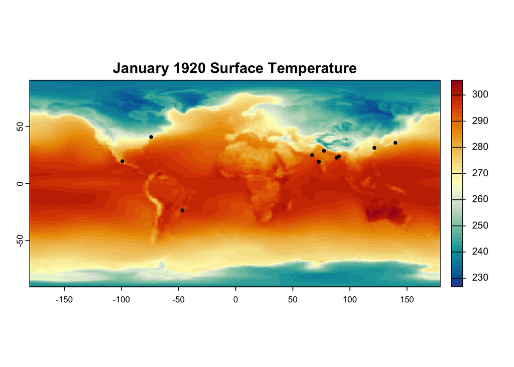

```r
#?plot

#create plot with surface temperatures
plot(R_Data_Historic[[1]], #plotting the R_Data_Historic SpatRaster, selecting index 1 = 1920
     main = "January 1920 Surface Temperature", #Title
     col = hcl.colors(50, "RdYlBu", rev = TRUE)
     ) #Reversing so blue corresponds with lowest values and red corresponds with higher values
#add points from top 10 cities
points(cities_10,
       col = "black",
       pch = 16, #filled circle
       )

#add legend
legend("bottomleft",
       legend = "Top 10 Most Populous Cities",
       pch = 16, #filled circle
       col = "black")
```

```r
#note these temperature values are in Kelvins

#hcl.colors offers contiguous colors, brighter than RColorBrewer. I feel like RColorBrewer RdYlBu was too dull and made it difficult to see the midtones.

##https://clauswilke.com/art/post/colors-color-spaces
```

```r
#I am going to experiment with using tidyterra to make terra compatible with ggplot.
##install.packages("tidyterra")
```

```r
#load libraries
library(tidyterra)
library(tidyverse)
#referenced https://dieghernan.github.io/tidyterra/
```

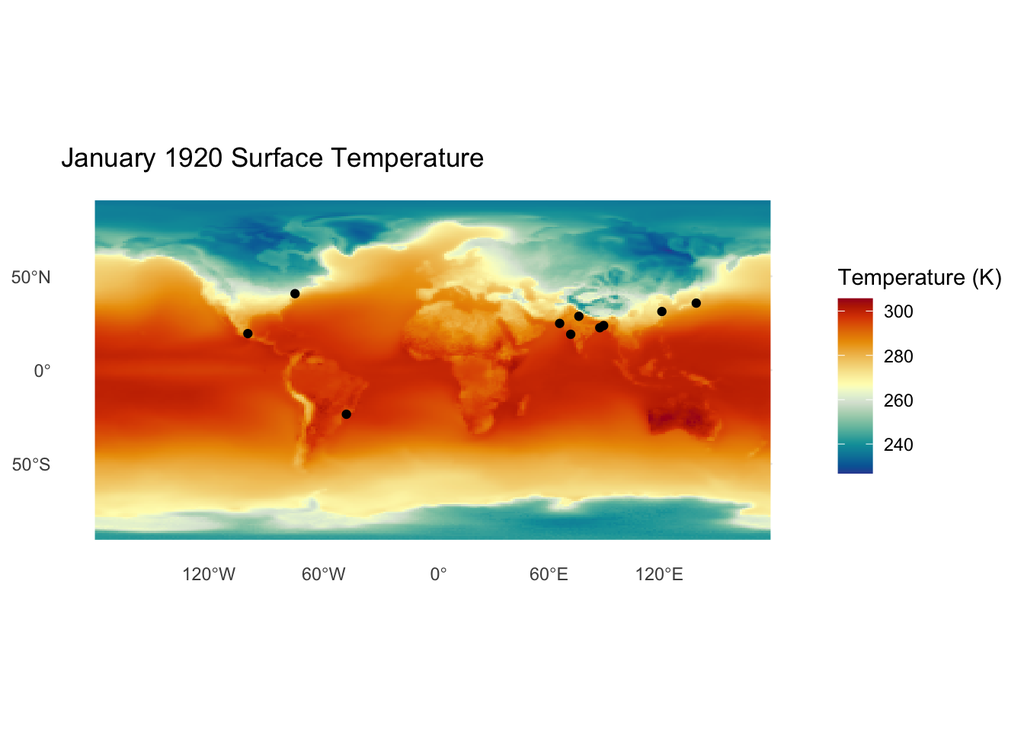

```r
#tidyterra version of plot. I feel like ggplot is a little bit more structured and allows me to make a plot quickly, but base R offers more space for customization

ggplot()+
  geom_spatraster(data = R_Data_Historic[[1]])+
  geom_spatvector(data = cities_10, color = "black")+
  scale_fill_gradientn(colours = hcl.colors(50, "RdYlBu", rev = TRUE))+
  labs(fill = "Temperature (K)",
       title = "January 1920 Surface Temperature")+
  theme_minimal()
```

2c. What about the plot gives you confidence this is actually showing temperature data from a January? Use code to show the units of the temperature data?

**Answer: Visually, I can see that Australia has a very saturated red hue, indicating that they are experiencing warm weather. Australias warm season occurs during the northern hemispheres cold season, If you look at North America, you can see its mostly a neutral to cooler hue, indicating it is in a colder season like January.**

```r
#look at units with code
units(R_Data_Historic) #all layers
```

[output not shown]

[output cut: 43 more lines]

```r
units(R_Data_Historic[[1]]) #1920 layer
```

```
## [1] "K"
```

3a. Read in the observed temperature data as a SpatRaster, using “tmp” for the sub-dataset argument

```r
#read in observed temperature data

obs_temp <- rast("~/Downloads/ESP_106/ESP 106/esp106_CandyGArellano/Week 7/Data/Observed Temp Data/cru_ts4.03.1991.2000.tmp.dat.nc", subds = "tmp")
```

3b. Note that this climate model data is for 1920-2005 but the observation data is only from 1991-2000. Subset the climate model data to just the years 1991-2000. Also change the units to match those of the observed climate data.

```r
# hint: have a look at ?terra::time to see how to get years

# time(R_Data_Historic) gives values back.  year,month,day format given
time_values <- time(R_Data_Historic) #place time values in vector

#keep values from 1991-2000. Note this part is purely the boolean vector/logical vector (True/False)
time_boolean<- time_values >= as.Date("1991-01-01") & time_values <= as.Date("2000-12-31")

# subset layers, for every True value, keep the layer
time_2000 <- R_Data_Historic[[time_boolean]]
```

4. Use `terra::extract` to produce two data-frames, one with observed and one with modeled temperature values for each city. Change the units of the modeled data so they match the units of the observed data.

```r
?extract #about terra::extract
```

```
## Help on topic 'extract' was found in the following packages:
##
##   Package               Library
##   tidyr                 /Library/Frameworks/R.framework/Versions/4.4-x86_64/Resources/library
##   magrittr              /Library/Frameworks/R.framework/Versions/4.4-x86_64/Resources/library
##   terra                 /Library/Frameworks/R.framework/Versions/4.4-x86_64/Resources/library
##
##
## Using the first match ...
```

```r
#Notes
##extract(x,y..), where x can be SpatVector/SpatRaster and y can be SpatVecotr, 2 col matrix etc.

#df with observed temperature values
## given : city_obs <- extract( ___, ___)

city_obs <- terra::extract(obs_temp, cities_10) #obs_temp is observed temperatures from 1991-2000. sub_cities is SpatVdctor of the top 10 most populous cities, assuming we are focusing on those rather than hundred of locations

#df with modeled temperature values
## given: city_sim <- extract( ___, ___)

city_sim <- terra::extract(time_2000, cities_10) #time_subset is the historic temperature data between 1991 and 2000.

#PS I used "terra::extract" bc R was picking up extract() from some other package, probably tidyverse
```

```r
#data frames
city_obs <- data.frame(t(city_obs))
city_sim <- data.frame(t(city_sim))
```

```r
##I get  an error later on, so I am cleaning the ID out here.

##"Error in `$<-.data.frame`(`*tmp*`, time, value = c(7685, 7715, 7744, 7775,  : replacement has 120 rows, data has 121"when trying to create a time vector from the previous rasters. Here is my troubleshooting.


#if df, I should be able to use glimpse
glimpse(city_obs) #121 row
```

```
## Rows: 121
## Columns: 10
## $ X1  <dbl> 1.000000, 4.900000, 4.900000, 8.900001, 14.500000, 18.100000, 23.0…
## $ X2  <dbl> 2.0, 23.1, 24.5, 26.8, 29.0, 30.6, 29.4, 27.4, 27.1, 27.7, 28.2, 2…
## $ X3  <dbl> 3.0, 21.7, 22.4, 21.9, 20.6, 18.5, 17.7, 16.1, 17.4, 18.3, 19.8, 2…
## $ X4  <dbl> 4.000000, 11.100000, 12.200000, 15.400001, 16.400000, 16.700001, 1…
## $ X5  <dbl> 5.000000, 0.800000, 3.800000, 6.600000, 12.100000, 19.100000, 22.3…
## $ X6  <dbl> 6.0, 13.0, 16.9, 22.3, 27.2, 32.3, 33.2, 32.2, 29.5, 29.3, 25.6, 1…
## $ X7  <dbl> 7.0, 4.4, 5.9, 7.9, 13.6, 18.7, 23.7, 28.1, 26.8, 23.8, 17.8, 12.0…
## $ X8  <dbl> 8.0, 19.4, 24.4, 28.7, 30.4, 31.0, 29.9, 29.7, 29.1, 28.8, 27.9, 2…
## $ X9  <dbl> 9.0, 17.8, 22.4, 26.9, 28.1, 28.1, 28.2, 28.7, 28.7, 28.1, 26.9, 2…
## $ X10 <dbl> 10.0, 17.4, 19.1, 23.8, 28.9, 31.6, 33.2, 31.8, 30.3, 29.3, 27.3, …
```

```r
glimpse(city_sim) #121 row
```

```
## Rows: 121
## Columns: 10
## $ X1  <dbl> 1.0000, 282.7177, 279.9959, 279.4496, 281.4954, 286.2001, 290.7401…
## $ X2  <dbl> 2.0000, 297.0592, 296.3456, 297.4111, 301.2054, 301.7224, 301.0786…
## $ X3  <dbl> 3.0000, 294.0486, 295.2776, 295.1078, 293.6903, 292.4758, 291.0389…
## $ X4  <dbl> 4.0000, 280.5096, 278.1967, 282.5321, 284.8211, 287.0096, 286.9083…
## $ X5  <dbl> 5.0000, 272.1549, 273.0930, 272.0157, 280.9520, 283.9235, 290.2113…
## $ X6  <dbl> 6.0000, 287.2572, 284.4014, 291.7807, 299.5176, 306.0105, 309.9316…
## $ X7  <dbl> 7.0000, 278.9210, 275.5522, 277.2562, 281.6122, 286.3092, 290.5059…
## $ X8  <dbl> 8.0000, 294.3860, 292.0688, 295.2435, 298.4943, 300.0432, 301.1274…
## $ X9  <dbl> 9.0000, 293.4587, 290.4241, 294.8150, 300.4128, 302.5936, 300.8204…
## $ X10 <dbl> 10.0000, 290.8350, 287.3050, 293.6987, 298.7125, 301.4959, 302.944…
```

```r
length(time(obs_temp)) #120
```

```
## [1] 120
```

```r
head(time(obs_temp)) #dates, no ID
```

```
## [1] "1991-01-16" "1991-02-15" "1991-03-16" "1991-04-16" "1991-05-16"
## [6] "1991-06-16"
```

```r
head(rownames(city_obs), 5)  #contains ID
```

```
## [1] "ID"    "tmp_1" "tmp_2" "tmp_3" "tmp_4"
```

```r
head(rownames(city_sim), 5) #contains ID
```

```
## [1] "ID"         "TREFHT_852" "TREFHT_853" "TREFHT_854" "TREFHT_855"
```

```r
city_obs <- city_obs[rownames(city_obs) != "ID", ,
                     drop = FALSE] #keep as df
city_sim <- city_sim[rownames(city_sim) != "ID", ,
                     drop = FALSE] #keep as df
```

We have to do a bit of data-wrangling to compare modeled and observed temperature data for each city.

5a. Add a column to both data-frames with the names of the cities using the NAME column from the city data frame

```r
#cols represent cities
colnames(city_obs) <- cities_10$NAME
colnames(city_sim) <- cities_10$NAME
```

```r
#time vector from given rasters (the ones I extracted from previously)
city_obs$time <- time(obs_temp)
city_sim$time <- time(time_2000)
```

5b. Use `tidyr::pivot_longer` to turn both data-frames into tidy data-frames, with one row for each unique city-month combination

```r
#Hint: you want to use the first 10 columns (cities) to pivot (cols argument in the pivot_longer function). Use the values_to argument to name the temperature data column either "observed" or "simulated".

#turn dfs into tidy dfs. tidyverse already loaded

##frame: city_obs <- ________

city_obs_long <- city_obs %>%
  pivot_longer(cols = 1:10, #alternatively, can't I do -time? > ask Prof RH
               names_to = "city",
               values_to = "observed")

##frame: city_sim <- ________

city_sim_long <- city_sim %>%
  pivot_longer(cols = 1:10,
               names_to = "city",
               values_to = "simulated")
```

5c. Notice that the modeled and observed rasters have used slightly different conventions for naming the months. You can see this in the “name” column of the two data frames you made in 5b. The model output uses the first of the month (e.g. 1991.02.01) whereas the observational data uses the middle of the month (e.g. 1991.01.16). This is a problem since we want to merge together the two data frames to compare observed and simulated data.

To merge the two data frames together, first we need to “chop off” the last two digits in the month ids in both data frames. One way to do this is to use the `substr` function to return some subset of a character vector.

change the variable “time” from Date to “yearmon” (character)

```r
#keep only year and month. note that its going to be in xxxx-xx-xx format, where year-month-day
city_obs_long <- city_obs_long %>%
  mutate(yearmon = substr(as.character(time), 1, 7)) #7 is where year and month end, chopping odd last two digits

city_sim_long <- city_sim_long %>%
  mutate(yearmon = substr(as.character(time), 1, 7))

#check results
head(city_obs_long$yearmon)
```

```
## [1] "1991-01" "1991-01" "1991-01" "1991-01" "1991-01" "1991-01"
```

```r
head(city_sim_long$yearmon)
```

```
## [1] "1991-01" "1991-01" "1991-01" "1991-01" "1991-01" "1991-01"
```

5d. Merge the observed and modeled city data into a single data-frame. In this case you could use `cbind`, but that it is safer to use `merge`

```r
#Hint: you will want to specify two columns in the "by" argument in merge(). Think about what two columns those should be (i.e. what combination of columns identifies a unique observation that matches across the two dataframes)
#rename  df_merged as all_city

all_city <- merge(city_obs_long, #observed city data
                   city_sim_long, #modeled city data
                   by = c("city", "yearmon"))
```

5e. Make a plot showing observed vs modeled temperature for the 10 cities. Add a 1:1 line which showing the perfect match between observed and modeled data that one would like to see. You can use base plot or ggplot.

```r
#check if units match, since I noticed my original plots axis intervals were kind of mismatched and my line was not showing up
obs_temp # is in Celsius
```

```
## class       : SpatRaster
## dimensions  : 360, 720, 120  (nrow, ncol, nlyr)
## resolution  : 0.5, 0.5  (x, y)
## extent      : -180, 180, -90, 90  (xmin, xmax, ymin, ymax)
## coord. ref. : lon/lat WGS 84 (CRS84) (OGC:CRS84)
## source      : cru_ts4.03.1991.2000.tmp.dat.nc:tmp
## varname     : tmp (near-surface temperature)
## names       :           tmp_1,           tmp_2,           tmp_3,           tmp_4,           tmp_5,           tmp_6, ...
## unit        : degrees Celsius, degrees Celsius, degrees Celsius, degrees Celsius, degrees Celsius, degrees Celsius, ...
## time (days) : 1991-01-16 to 2000-12-16 (2 steps)
```

```r
R_Data_Historic #is in Kelvins
```

```
## class       : SpatRaster
## dimensions  : 192, 288, 1032  (nrow, ncol, nlyr)
## resolution  : 1.25, 0.9424084  (x, y)
## extent      : -180.625, 179.375, -90.4712, 90.4712  (xmin, xmax, ymin, ymax)
## coord. ref. : +proj=longlat +datum=WGS84 +no_defs
## source      : spat_458633cbf7db_17798_SskviV5XwhZb4QV.tif
## varname     : TREFHT (Reference height temperature)
## names       : TREFHT_1, TREFHT_2, TREFHT_3, TREFHT_4, TREFHT_5, TREFHT_6, ...
## min values  : 226.7396, 225.2588, 218.4585, 210.3827, 202.6484, 201.3777, ...
## max values  : 305.6568, 305.2307, 305.3159, 306.6289, 312.2310, 313.3987, ...
## unit        :        K,        K,        K,        K,        K,        K, ...
## time (days) : 1920-02-01 to 2006-01-01 (2 steps)
```

```r
#units do not match. I am going to go ahead and turn K into C in a clean df "all_city_clean"

all_city_clean <- all_city %>%
  mutate(simulated = simulated - 273.15) #go ahead and fix. C = K - 273.15
```

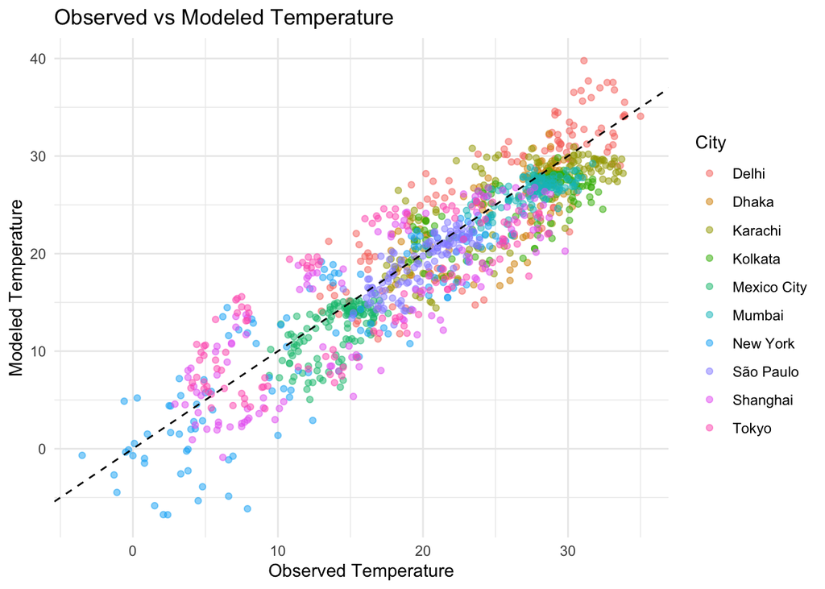

```r
#plot using ggplot()
ggplot(all_city_clean,
       aes(x = observed, y = simulated, color = city))+ #define axis'
  geom_point(alpha = 0.5)+ #alpha at 0.5 for transparency, since there are many overlapping values
  geom_abline(slope = 1, intercept = 0, linetype = "dashed", color = "black")+ #create 1 x 1 line
  labs(title = "Observed vs Modeled Temperature",#labeling title, x axis, and y Axis
       x = "Observed Temperature",
       y = "Modeled Temperature",
       color = "City")+ #color by city
  theme_minimal()
```

#Part 2

In the second part of the lab, we will use projections of future temperature change (until 2080) and a map of the distribution of population in 2020 to get global, population-weighted projected warming.

```r
#read in netCDF as SpatRaster
netCDF <- rast("~/Downloads/ESP_106/ESP 106/esp106_CandyGArellano/Week 7/Data/Climate Model Data_Future/b.e11.BRCP85C5CNBDRD.f09_g16.002.cam.h0.TREFHT.200601-208012.nc", subds = "TREFHT")

#look at the extent
ext(netCDF)
```

```
## SpatExtent : -0.625, 359.375, -90.4712041884817, 90.4712041884817 (xmin, xmax, ymin, ymax)
```

```r
#rotate
netCDF <- rotate(netCDF, left=TRUE)
```

```
## |---------|---------|---------|---------|=========================================
```

```r
#check extent
ext(netCDF) #rotation successful
```

```
## SpatExtent : -180.625, 179.375, -90.4712041884817, 90.4712041884817 (xmin, xmax, ymin, ymax)
```

```r
netCDF #is in Kelvins
```

```
## class       : SpatRaster
## dimensions  : 192, 288, 900  (nrow, ncol, nlyr)
## resolution  : 1.25, 0.9424084  (x, y)
## extent      : -180.625, 179.375, -90.4712, 90.4712  (xmin, xmax, ymin, ymax)
## coord. ref. : +proj=longlat +datum=WGS84 +no_defs
## source      : spat_45867d12b8ff_17798_GdaPwXHptgIOPSx.tif
## varname     : TREFHT (Reference height temperature)
## names       : TREFHT_1, TREFHT_2, TREFHT_3, TREFHT_4, TREFHT_5, TREFHT_6, ...
## min values  : 227.8591, 226.3425, 216.4508, 209.2771, 204.3515, 210.9332, ...
## max values  : 306.0093, 306.0674, 307.2524, 307.4044, 310.5476, 314.0392, ...
## unit        :        K,        K,        K,        K,        K,        K, ...
## time (days) : 2006-02-01 to 2081-01-01 (2 steps)
```

```r
#convert from Kelvin to Celsius
netCDR <- netCDF - 273.15
```

```
## |---------|---------|---------|---------|=========================================
```

6b. Compute the projected *annual* trend in global climate. Use `tapp` for this temporal aggregation.

```r
#PLAN: I am assuming that I need to get a rate of change to represent "trend". I am going to run a regression for project warming over time



?tapp
##by using tapp, i can combine the month layers into a year (annual).. index = c(1,1,1,2,2,2). note temporal> aggregating over time

head(time(netCDF)) #same time format as prev rasters
```

```
## [1] "2006-02-01" "2006-03-01" "2006-04-01" "2006-05-01" "2006-06-01"
## [6] "2006-07-01"
```

```r
tail(time(netCDF))
```

```
## [1] "2080-08-01" "2080-09-01" "2080-10-01" "2080-11-01" "2080-12-01"
## [6] "2081-01-01"
```

```r
#extract time

##monthly time object
t <- time(netCDF)

##creating year groups
yr <- format(t, "%Y")

#aggregate to annual mean
annual_mean <- tapp(netCDF, #SpatRaster
                    index = yr, #index can be done
                    fun = mean, #applying mean to average the times into 1 value/layer
                    na.rm = TRUE #remove na values
                    )
#inspect
annual_mean #years are like "X2005"
```

```
## class       : SpatRaster
## dimensions  : 192, 288, 76  (nrow, ncol, nlyr)
## resolution  : 1.25, 0.9424084  (x, y)
## extent      : -180.625, 179.375, -90.4712, 90.4712  (xmin, xmax, ymin, ymax)
## coord. ref. : +proj=longlat +datum=WGS84 +no_defs
## source(s)   : memory
## names       :    X2006,    X2007,    X2008,    X2009,    X2010,    X2011, ...
## min values  : 215.2909, 217.5892, 217.3202, 217.0331, 218.8872, 218.0642, ...
## max values  : 303.1823, 303.1991, 302.6534, 303.0816, 304.2696, 303.0414, ...
```

```r
#referenced https://r4ds.hadley.nz/datetimes.html, which shows R date formats
```

```r
#area weights
lat <- init(annual_mean[[1]], "y") #latitude raster

w_area <- cos(lat * pi /180 )
w_area <-mask(w_area, annual_mean[[1]]) #keep weights where the temperatures are not NA values

#area-weighted global mean temperature per year (aiming for one value per annual layer)
global_mean_aw <- global(annual_mean, ful = "mean",
                         weights = w_area, na.rm = TRUE)
```

```r
#year vector
year_vec <- as.integer(sub("^X", "", names(annual_mean)))

#area-weighted global mean
global_vec <- global_mean_aw[,1]

#df for regression
df_global <- data.frame(year = year_vec, temp = global_vec)

# run linear regression
lm_global <- lm(temp ~ year, data = df_global)
summary(lm_global)
```

```
##
## Call:
## lm(formula = temp ~ year, data = df_global)
##
## Residuals:
##      Min       1Q   Median       3Q      Max
## -1.28402 -0.08648  0.01520  0.11678  0.39364
##
## Coefficients:
##              Estimate Std. Error t value Pr(>|t|)
## (Intercept) 1.973e+02  2.209e+00   89.34   <2e-16 ***
## year        4.457e-02  1.081e-03   41.24   <2e-16 ***
## ---
## Signif. codes:  0 '***' 0.001 '**' 0.01 '*' 0.05 '.' 0.1 ' ' 1
##
## Residual standard error: 0.2067 on 74 degrees of freedom
## Multiple R-squared:  0.9583, Adjusted R-squared:  0.9577
## F-statistic:  1701 on 1 and 74 DF,  p-value: < 2.2e-16
```

```r
# slope to represent temp change per year
coef(lm_global)["year"]
```

```
##       year
## 0.04457487
```

Use these data in the questions below.